# Independent Bayesian Validation of the Np AAR Age Calculator

2026-10-08

## Overview

This notebook supports the manuscript “A calibration-based age calculator for high-latitude Quaternary foraminifera using amino acid racemization” by Kaufman and others. The manuscript’s age calculator computes the age of a *Neogloboquadrina pachyderma* (Np) sample from the D/L of aspartic acid (Asp) alone, through the time-dependent kinetics (TDK0) equation. Glutamic acid (Glu) is not combined into the age. Its simple power-law (SPK0) age is retained only as a quality check, because the Glu log-age residual equals the Asp residual plus independent noise and so carries no age information that Asp does not already carry.

We test that claim, and the calculator itself, against an independent Bayesian implementation written in R:

- **Test 1 (published constants):** the manuscript’s TDK0 (Asp) and SPK0 (Glu) calibration constants and their residual correlation are supplied directly to a Bayesian MCMC inversion (`log_lik_two_acid_age()` in `R/age_inversion.R`) that uses *both* amino acids, through a bivariate-normal correlated-residual likelihood, to infer a full posterior distribution for each sample’s age. If Glu carries no independent age information, this two-acid posterior should return the Asp-only age. No calibration constants are re-estimated, so the test isolates the question of how the two acids’ evidence combines.
- **Test 2 (independent joint Bayesian calibration refit):** both calibration curves *and* their shared residual correlation are estimated simultaneously from the raw D/L data by MCMC (`log_posterior_age_calibration()` in `R/age_calibration.R`), and ages are then inverted from that independently refit calibration.

The earlier version of this notebook (release v0.1-presubmission) compared the Bayesian inversion with a blended Asp + Glu calculator based on generalized least squares. The manuscript no longer uses that calculator, and it has been removed here.

## Calibration models

Asp D/L-age data are described by **time-dependent kinetics (TDK)**, and Glu by **simple power-law kinetics (SPK)**, both with the origin fixed at zero:

$$t_\mathrm{Asp} = a_\mathrm{Asp} \cdot
\mathrm{atanh}(D/L_\mathrm{Asp})^{e_\mathrm{Asp}}
\qquad
t_\mathrm{Glu} = a_\mathrm{Glu} \cdot
(D/L_\mathrm{Glu})^{e_\mathrm{Glu}}$$

`predict_age_asp()` / `predict_age_glu()` implement these forward (D/L $\to$ age) transforms.

## The calibration dataset

The 140-sample Np calibration dataset (Table S1 of the manuscript; Arctic Ocean, Nordic Seas, North Atlantic, and Southern Ocean cores; ages 2 ka to 1.4 Ma). The 32 samples from core MD99-2289 were analyzed at the University of York with a 22 hr hydrolysis, and their D/L values have already been normalized to 6 hr equivalents in Table S1.

```r
np <- read.csv("data/np_calibration.csv")
nrow(np)
```

```
#> [1] 140
```

```r
table(np$region)
```

```
#>
#>   Arctic Ocean    Nordic Seas North Atlantic Southern Ocean
#>             38             56             17             29
```

```r
head(np[, c("UAL", "core", "age_ka", "DL_Asp", "SD_Asp", "DL_Glu", "SD_Glu", "n_used")])
```

```
#>                   UAL  core age_ka DL_Asp SD_Asp DL_Glu SD_Glu n_used
#> 1               23158 PC493    785  0.478  0.036  0.267  0.039      9
#> 2               23165 PC493      7  0.148  0.015  0.063  0.007      9
#> 3        23044, 23140 PC493    115  0.242  0.008  0.093  0.009     12
#> 4 23045, 23156, 23590 PC493    401  0.404  0.030  0.203  0.029     24
#> 5        23046, 23157 PC493    602  0.442  0.021  0.241  0.023     17
#> 6        23166, 23167 PC493    915  0.510  0.050  0.322  0.053     29
```

```r
cal_data <- data.frame(age_ka = np$age_ka, DL_Asp = np$DL_Asp, DL_Glu = np$DL_Glu)
```

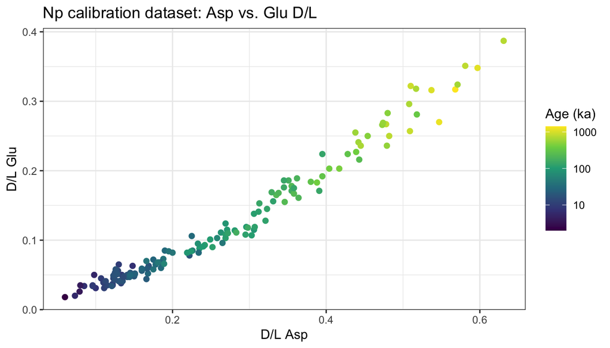

```r
ggplot(np, aes(x = DL_Asp, y = DL_Glu, colour = age_ka)) +
  geom_point(size = 1.8) +
  scale_colour_viridis_c(trans = "log10", name = "Age (ka)") +
  labs(x = "D/L Asp", y = "D/L Glu", title = "Np calibration dataset: Asp vs. Glu D/L") +
  theme_bw()
```

## The Asp-only reference calculator

`predict_age_asp_only()` (`R/asp_calculator.R`) reproduces the formulas of the manuscript’s spreadsheet calculator: the TDK0 age from Asp, with a Student-t prediction interval whose variance combines the calibration mean squared error, the sample’s leverage on the fitted line, and the standard error of the mean D/L propagated through the model derivative. The constants in `asp_calibration_constants` are copied from the spreadsheet’s Constants sheet.

As a check that the dataset here is the one the manuscript was fit to, we refit both curves by ordinary least squares (OLS) regression of `log(age)` on `log(f(D/L))`:

```r
fit_asp <- lm(log(age_ka) ~ log(atanh(DL_Asp)), data = np)
fit_glu <- lm(log(age_ka) ~ log(DL_Glu), data = np)
cst <- asp_calibration_constants

ols_check <- data.frame(
  parameter = c("a_Asp", "e_Asp", "sigma_Asp", "a_Glu", "e_Glu", "sigma_Glu", "rho"),
  refit_here = c(exp(coef(fit_asp)[1]), coef(fit_asp)[2], summary(fit_asp)$sigma,
                 exp(coef(fit_glu)[1]), coef(fit_glu)[2], summary(fit_glu)$sigma,
                 cor(resid(fit_asp), resid(fit_glu))),
  published = c(cst$a_Asp, cst$e_Asp, sqrt(cst$MSE_Asp),
                cst$a_Glu, cst$e_Glu, sqrt(cst$MSE_Glu), cst$rho),
  row.names = NULL
)
ols_check$pct_diff <- 100 * (ols_check$refit_here - ols_check$published) / ols_check$published
knitr::kable(ols_check, digits = 4)
```

| parameter | refit_here | published | pct_diff |
| --- | --- | --- | --- |
| a_Asp | 2579.0076 | 2580.1717 | -0.0451 |
| e_Asp | 2.5371 | 2.5375 | -0.0150 |
| sigma_Asp | 0.3282 | 0.3282 | 0.0042 |
| a_Glu | 7568.7685 | 7592.0704 | -0.3069 |
| e_Glu | 2.0098 | 2.0117 | -0.0911 |
| sigma_Glu | 0.4132 | 0.4131 | 0.0411 |
| rho | 0.7941 | 0.7945 | -0.0464 |

The refit reproduces the published residual standard deviations and correlation to the third decimal place and the scale parameters to within a few tenths of a percent. The small remaining differences are consistent with Table S1 reporting ages rounded to the nearest ka. All tests below use the published constants.

The spreadsheet’s Glu quality check can be reproduced from the same constants:

```r
asp_ref <- predict_age_asp_only(np$DL_Asp, np$SD_Asp, np$DL_Glu, np$SD_Glu, np$n_used)
disc <- log(asp_ref$t_Asp / asp_ref$t_Glu)
data.frame(
  sd_ln_discordance   = sd(disc),
  mean_ln_discordance = mean(disc),
  n_check_95          = sum(asp_ref$flag != "ok"),
  n_fail_99           = sum(asp_ref$flag == "FAIL (>99%)")
) |> knitr::kable(digits = 3)
```

| sd_ln_discordance | mean_ln_discordance | n_check_95 | n_fail_99 |
| --- | --- | --- | --- |
| 0.25 | 0.001 | 7 | 4 |

### Why Glu should receive no weight

For two correlated, unbiased estimates of log age with residual standard deviations $\sigma_\mathrm{Asp}$ and $\sigma_\mathrm{Glu}$ and correlation $\rho$, the optimal (generalized least squares, or equivalently flat-prior Bayesian) weight on Glu is proportional to $\sigma_\mathrm{Asp}(\sigma_\mathrm{Asp} - \rho\,\sigma_\mathrm{Glu})$. It vanishes when $\rho = \sigma_\mathrm{Asp} / \sigma_\mathrm{Glu}$:

```r
sA <- sqrt(cst$MSE_Asp); sG <- sqrt(cst$MSE_Glu); r <- cst$rho
C  <- r * sA * sG
data.frame(
  rho                  = r,
  sigma_Asp_over_Glu   = sA / sG,
  Glu_weight           = (sA^2 - C) / (sA^2 + sG^2 - 2 * C),
  sigma_Asp_only       = sA,
  sigma_two_acid       = sqrt((sA^2 * sG^2 - C^2) / (sA^2 + sG^2 - 2 * C))
) |> knitr::kable(digits = 4)
```

| rho | sigma_Asp_over_Glu | Glu_weight | sigma_Asp_only | sigma_two_acid |
| --- | --- | --- | --- | --- |
| 0.7945 | 0.7945 | 0 | 0.3282 | 0.3282 |

At the calibration level, the observed correlation sits almost exactly at the value at which Glu gets zero weight, and combining the two acids leaves the Asp-only uncertainty unchanged. For an individual sample the two prediction variances also include leverage and measurement error, which can move the ratio away from $\rho$, so the Glu weight is not exactly zero for every sample. Test 1 measures how much that matters.

## Test 1: supplying the published constants

The Bayesian inversion uses a bivariate-normal likelihood for the Asp and Glu log-age residuals, a flat prior on log age between 0.5 and 3000 ka, and a random-walk Metropolis sampler. For each sample, the residual standard deviations are set to the *same per-sample prediction variances* that the calculator uses (`V_Asp`, and the analogous `V_Glu`), so that the Bayesian inversion and the Asp-only calculator use the same information about each sample. The only difference between them is that the Bayesian posterior also uses Glu.

### Two worked examples

The two worked examples in the spreadsheet calculator. Example 2 was measured with a 22 hr hydrolysis and is first normalized to its 6 hr equivalent, as the spreadsheet does.

```r
examples <- data.frame(
  sample = c("Example 1", "Example 2"),
  N = c(6, 5), hydrolysis_hr = c(6, 22),
  DL_Asp = c(0.350, 0.232), SD_Asp = c(0.011, 0.012),
  DL_Glu = c(0.153, 0.090), SD_Glu = c(0.015, 0.011)
)
is22 <- examples$hydrolysis_hr == 22
examples$DL_Asp[is22] <- normalize_22hr(examples$DL_Asp[is22], cst$delta_Asp)
examples$DL_Glu[is22] <- normalize_22hr(examples$DL_Glu[is22], cst$delta_Glu)

two_acid_params <- function(ref, constants = cst) {
  list(a_Asp = constants$a_Asp, e_Asp = constants$e_Asp, sigma_Asp = sqrt(ref$V_Asp),
       a_Glu = constants$a_Glu, e_Glu = constants$e_Glu, sigma_Glu = sqrt(ref$V_Glu),
       rho = constants$rho)
}

set.seed(1)
example_runs <- lapply(seq_len(nrow(examples)), function(i) {
  ex  <- examples[i, ]
  ref <- predict_age_asp_only(ex$DL_Asp, ex$SD_Asp, ex$DL_Glu, ex$SD_Glu, ex$N)
  mc  <- invert_two_acid_age(ex$DL_Asp, ex$DL_Glu, two_acid_params(ref),
                             n_iter = 50000, proposal_sd = 2.5 * ref$sigma_Asp)
  list(ref = ref, mcmc = mc)
})

do.call(rbind, lapply(seq_along(example_runs), function(i) {
  ref  <- example_runs[[i]]$ref
  post <- summarize_age_posterior(example_runs[[i]]$mcmc, burnin = 5000)
  data.frame(sample = examples$sample[i],
             asp_age = ref$t_Asp, asp_lo66 = ref$lo66, asp_hi66 = ref$hi66,
             bayes_median = post$median_ka, bayes_lo66 = post$lo66_ka,
             bayes_hi66 = post$hi66_ka, glu_age = ref$t_Glu, check = ref$flag)
})) |> knitr::kable(digits = 1)
```

| sample | asp_age | asp_lo66 | asp_hi66 | bayes_median | bayes_lo66 | bayes_hi66 | glu_age | check |
| --- | --- | --- | --- | --- | --- | --- | --- | --- |
| Example 1 | 200.6 | 146 | 275.6 | 202.0 | 147.2 | 276.7 | 173.9 | ok |
| Example 2 | 36.0 | 26 | 49.8 | 36.2 | 26.3 | 50.0 | 34.2 | ok |

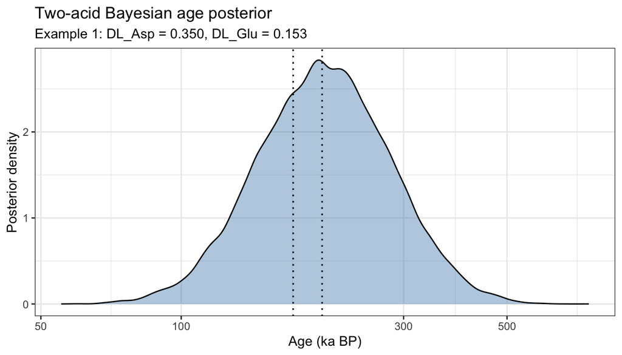

```r
plot_age_posterior(example_runs[[1]]$mcmc, burnin = 5000,
                   compare_ages_ka = c("Asp only" = example_runs[[1]]$ref$t_Asp,
                                       "Glu only" = example_runs[[1]]$ref$t_Glu)) +
  labs(subtitle = "Example 1: DL_Asp = 0.350, DL_Glu = 0.153")
```

### Full calibration-set comparison

For every one of the 140 calibration samples we compute the Asp-only age and 66% prediction interval with `predict_age_asp_only()`, and the two-acid Bayesian posterior median and 66% credible interval by MCMC. Because the prior is flat in log age and the likelihood is Gaussian in log age, the two-acid posterior also has a closed form (a precision-weighted mean of the two log ages), which we compute alongside the MCMC result to separate genuine differences from Monte Carlo noise.

```r
n_iter_full <- 100000
burnin_full <- 20000

closed_form_two_acid <- function(ref, rho) {
  C  <- rho * sqrt(ref$V_Asp * ref$V_Glu)
  wA <- ref$V_Glu - C
  wG <- ref$V_Asp - C
  data.frame(
    w_Glu  = wG / (wA + wG),
    median = exp((wA * log(ref$t_Asp) + wG * log(ref$t_Glu)) / (wA + wG)),
    sigma  = sqrt((ref$V_Asp * ref$V_Glu - C^2) / (wA + wG))
  )
}

run_full_comparison <- function(param_fn, seed) {
  set.seed(seed)
  do.call(rbind, lapply(seq_len(nrow(np)), function(i) {
    row <- np[i, ]
    ref <- predict_age_asp_only(row$DL_Asp, row$SD_Asp, row$DL_Glu, row$SD_Glu, row$n_used)
    mc  <- invert_two_acid_age(row$DL_Asp, row$DL_Glu, param_fn(ref),
                               n_iter = n_iter_full, proposal_sd = 2.5 * ref$sigma_Asp)
    post <- summarize_age_posterior(mc, burnin = burnin_full)
    data.frame(UAL = row$UAL, published_age_ka = row$age_ka,
               asp_age_ka = ref$t_Asp, asp_lo66_ka = ref$lo66, asp_hi66_ka = ref$hi66,
               bayes_median_ka = post$median_ka,
               bayes_lo66_ka = post$lo66_ka, bayes_hi66_ka = post$hi66_ka,
               acceptance = mc$acceptance_rate)
  })) |>
    mutate(pct_diff_median = 100 * (bayes_median_ka - asp_age_ka) / asp_age_ka,
           asp_width66     = asp_hi66_ka - asp_lo66_ka,
           bayes_width66   = bayes_hi66_ka - bayes_lo66_ka)
}

full_results_A <- run_full_comparison(two_acid_params, seed = 7)

cf_A <- closed_form_two_acid(asp_ref, cst$rho)
full_results_A$cf_median_ka   <- cf_A$median
full_results_A$cf_pct_diff    <- 100 * (cf_A$median - asp_ref$t_Asp) / asp_ref$t_Asp
full_results_A$cf_sigma_ratio <- cf_A$sigma / asp_ref$sigma_Asp
full_results_A$w_Glu          <- cf_A$w_Glu
range(full_results_A$acceptance)
```

```
#> [1] 0.41879 0.43351
```

```r
summary_A <- with(full_results_A, data.frame(
  method = c("MCMC posterior", "Closed-form posterior"),
  median_abs_pct_diff = c(median(abs(pct_diff_median)), median(abs(cf_pct_diff))),
  max_abs_pct_diff    = c(max(abs(pct_diff_median)), max(abs(cf_pct_diff))),
  n_over_1pct         = c(sum(abs(pct_diff_median) > 1), sum(abs(cf_pct_diff) > 1)),
  median_width_ratio  = c(median(bayes_width66 / asp_width66), median(cf_sigma_ratio))
))
knitr::kable(summary_A, digits = 2,
             col.names = c("", "Median abs. % diff", "Max abs. % diff",
                           "Samples > 1%", "Median 66% width ratio (two-acid / Asp)"))
```

|  | Median abs. % diff | Max abs. % diff | Samples > 1% | Median 66% width ratio (two-acid / Asp) |
| --- | --- | --- | --- | --- |
| MCMC posterior | 0.31 | 8.05 | 22 | 1 |
| Closed-form posterior | 0.16 | 7.91 | 17 | 1 |

The closed-form width ratio is the ratio of log-age standard deviations, which is equivalent to the ratio of 66% interval widths.

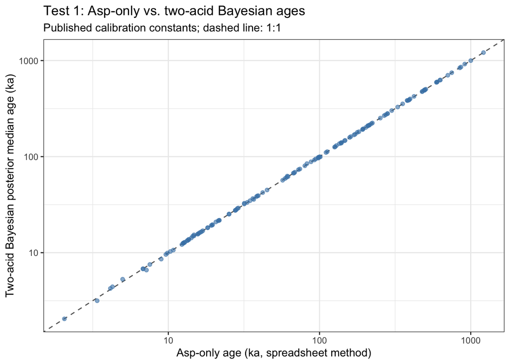

```r
ggplot(full_results_A, aes(x = asp_age_ka, y = bayes_median_ka)) +
  geom_abline(slope = 1, intercept = 0, linetype = "dashed", colour = "grey40") +
  geom_point(alpha = 0.6, colour = "steelblue") +
  scale_x_log10() + scale_y_log10() +
  labs(x = "Asp-only age (ka, spreadsheet method)",
       y = "Two-acid Bayesian posterior median age (ka)",
       title = "Test 1: Asp-only vs. two-acid Bayesian ages",
       subtitle = "Published calibration constants; dashed line: 1:1") +
  theme_bw()
```

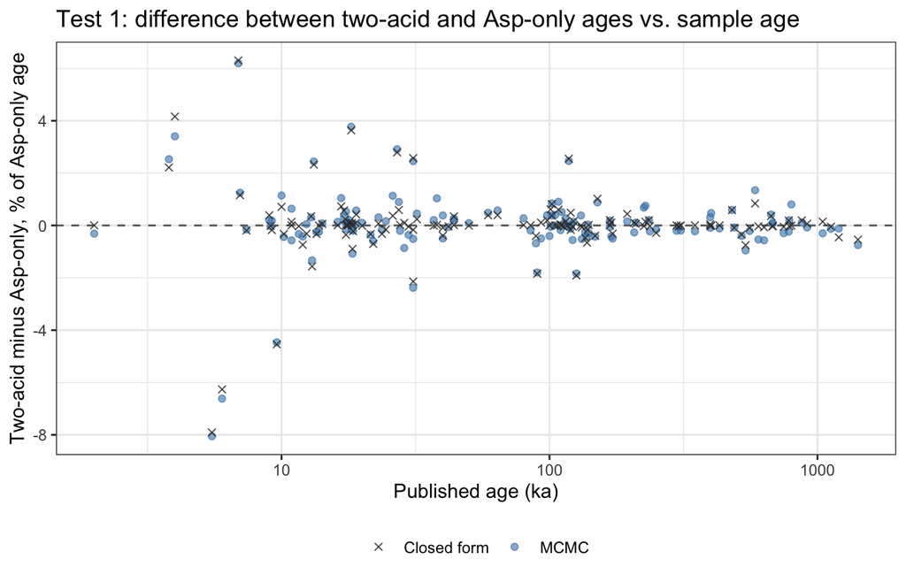

```r
ggplot(full_results_A, aes(x = published_age_ka)) +
  geom_hline(yintercept = 0, linetype = "dashed", colour = "grey40") +
  geom_point(aes(y = pct_diff_median, colour = "MCMC"), alpha = 0.6) +
  geom_point(aes(y = cf_pct_diff, colour = "Closed form"), alpha = 0.8, shape = 4) +
  scale_x_log10() +
  scale_colour_manual(values = c("MCMC" = "steelblue", "Closed form" = "grey20"), name = NULL) +
  labs(x = "Published age (ka)", y = "Two-acid minus Asp-only, % of Asp-only age",
       title = "Test 1: difference between two-acid and Asp-only ages vs. sample age") +
  theme_bw() + theme(legend.position = "bottom")
```

[figure not shown]

The eight samples with the largest closed-form two-acid vs. Asp-only differences

| UAL | core | published_age_ka | DL_Asp | DL_Glu | n_used | asp_age_ka | cf_median_ka | cf_pct_diff | w_Glu | glu_check |
| --- | --- | --- | --- | --- | --- | --- | --- | --- | --- | --- |
| 5921 | 88AR-P5 | 5.5 | 0.098 | 0.050 | 5 | 7.168 | 6.601 | -7.908 | -0.088 | FAIL (>99%) |
| 7468 | LOMROG07-08PC | 6.9 | 0.085 | 0.034 | 5 | 4.985 | 5.300 | 6.305 | 0.116 | check (>95%) |
| 21669, 21695 | MD95-2011 | 6.0 | 0.073 | 0.020 | 5 | 3.383 | 3.171 | -6.263 | 0.421 | ok |
| 6140 | HLY0503-8JPC | 9.6 | 0.107 | 0.045 | 2 | 8.973 | 8.565 | -4.543 | -0.093 | check (>95%) |
| 6134 | HLY0503-8JPC | 4.0 | 0.080 | 0.035 | 4 | 4.271 | 4.449 | 4.161 | 0.055 | FAIL (>99%) |
| 0562uH | MD99-2289 | 18.2 | 0.130 | 0.041 | 3 | 14.775 | 15.312 | 3.634 | -0.194 | ok |
| 0640uH | MD99-2289 | 27.0 | 0.175 | 0.072 | 2 | 31.787 | 32.675 | 2.794 | 0.151 | ok |
| 6510 | HLY0503-11MC-2 | 31.0 | 0.225 | 0.106 | 5 | 61.210 | 62.784 | 2.573 | 0.083 | ok |

| subset | n | median_abs_pct_diff_closed_form | max_abs_pct_diff_closed_form |
| --- | --- | --- | --- |
| < 30 ka | 53 | 0.32 | 7.91 |
| >= 30 ka | 87 | 0.11 | 2.57 |

```r
ggplot(full_results_A, aes(x = asp_width66, y = bayes_width66)) +
  geom_abline(slope = 1, intercept = 0, linetype = "dashed", colour = "grey40") +
  geom_point(alpha = 0.6, colour = "steelblue") +
  scale_x_log10() + scale_y_log10() +
  labs(x = "Asp-only 66% prediction interval width (ka)",
       y = "Two-acid Bayesian 66% credible interval width (ka)",
       title = "Test 1: interval widths, Asp-only vs. two-acid Bayesian",
       subtitle = "Published calibration constants; dashed line: 1:1") +
  theme_bw()
```

Supplied with the published calibration constants, the two-acid Bayesian posterior returns the Asp-only age. Across the 140 calibration samples the median absolute difference in the posterior median is 0.3% for the MCMC estimate, of which most is Monte Carlo noise: the exact closed-form posterior differs from the Asp-only age by a median of 0.16%. The 66% interval widths match (median ratio 1.00 for MCMC, 1.000 closed form). Differences exceeding 3% occur in only 6 samples, all younger than 20 ka, of which 4 are flagged by the Glu quality check. For each sample, leverage and measurement error move the Glu weight slightly away from zero, and the shift in log age equals that weight times the Asp-Glu log-age difference. It is therefore largest where the Glu weight departs most from zero or where the two ages disagree most (table above), and reaches several percent (at most 8%). These shifts are small relative to the ±32% half-width of the 66% interval.

## Test 2: an independent joint Bayesian calibration refit

As a more independent test, both calibration curves *and* their shared residual correlation are now estimated simultaneously from the raw D/L data by MCMC, using `log_lik_age_calibration()`’s bivariate-normal likelihood and weakly informative priors on all seven parameters (scale, exponent, and residual SD per acid, plus the Fisher-z-transformed correlation), with no numbers imported from the spreadsheet:

| Parameter | Prior |
| --- | --- |
| log(a_Asp) | Normal(log(3000), 3) |
| e_Asp | Normal(2.5, 2) |
| log(sigma_Asp) | Normal(log(0.4), 1.5) |
| log(a_Glu) | Normal(log(9000), 3) |
| e_Glu | Normal(2.2, 2) |
| log(sigma_Glu) | Normal(log(0.4), 1.5) |
| z_rho | Normal(0, 1) |

```r
init_cal <- c(log_a_Asp = log(3000), e_Asp = 2.5, log_sigma_Asp = log(0.4),
              log_a_Glu = log(9000), e_Glu = 2.2, log_sigma_Glu = log(0.4),
              z_rho = 0)

prop_cal <- c(log_a_Asp = 0.02, e_Asp = 0.015, log_sigma_Asp = 0.03,
              log_a_Glu = 0.02, e_Glu = 0.015, log_sigma_Glu = 0.03,
              z_rho = 0.06)

set.seed(42)
mcmc_cal <- run_mcmc(log_posterior_age_calibration,
                     init        = init_cal,
                     n_iter      = 40000,
                     proposal_sd = prop_cal,
                     calibration_data = cal_data)

cat("Acceptance rate:", round(mcmc_cal$acceptance_rate * 100, 1), "%\n")
```

```
#> Acceptance rate: 23.9 %
```

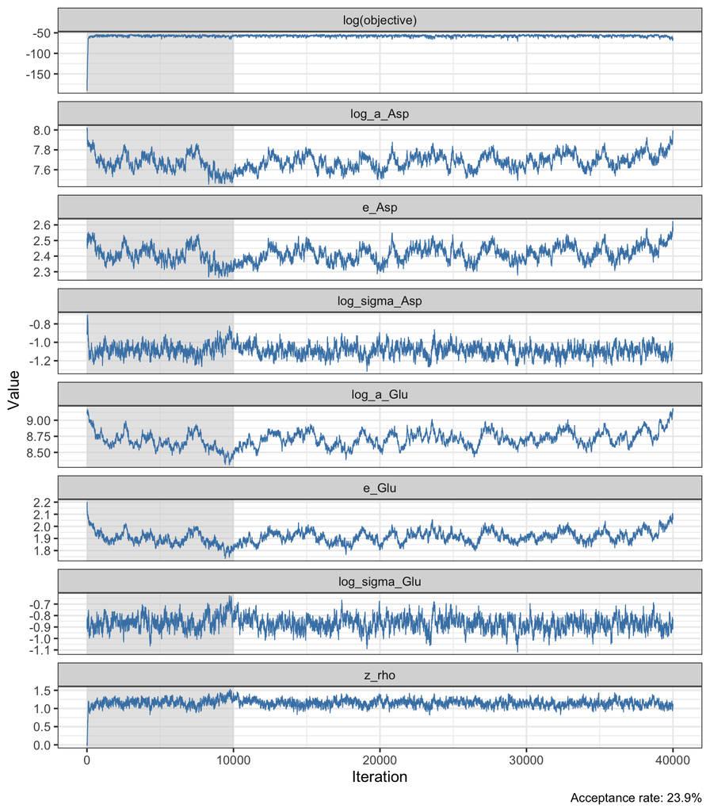

```r
plot_mcmc_chains(mcmc_cal, burnin = 10000)
```

To identify the source of any divergence, we repeat the refit with the residual correlation fixed at zero (`z_rho` held at 0 by giving it a zero proposal step), which makes the joint likelihood separable into the two acids’ independent fits:

```r
prop_cal_rho0 <- prop_cal
prop_cal_rho0[["z_rho"]] <- 0

set.seed(43)
mcmc_cal_rho0 <- run_mcmc(log_posterior_age_calibration,
                          init        = init_cal,
                          n_iter      = 40000,
                          proposal_sd = prop_cal_rho0,
                          calibration_data = cal_data)

cat("Acceptance rate:", round(mcmc_cal_rho0$acceptance_rate * 100, 1), "%\n")
```

```
#> Acceptance rate: 43.6 %
```

```r
calib_params_B    <- summarize_calibration(mcmc_cal, burnin = 10000)
calib_params_rho0 <- summarize_calibration(mcmc_cal_rho0, burnin = 10000)

param_names <- c("a_Asp", "e_Asp", "sigma_Asp", "a_Glu", "e_Glu", "sigma_Glu", "rho")
published   <- c(cst$a_Asp, cst$e_Asp, sqrt(cst$MSE_Asp),
                 cst$a_Glu, cst$e_Glu, sqrt(cst$MSE_Glu), cst$rho)
refit_B     <- unlist(calib_params_B[param_names])
refit_rho0  <- unlist(calib_params_rho0[param_names])

param_table <- data.frame(
  parameter = param_names,
  published = published,
  joint_refit = refit_B,
  joint_pct_diff = 100 * (refit_B - published) / published,
  rho0_refit = refit_rho0,
  rho0_pct_diff = 100 * (refit_rho0 - published) / published,
  row.names = NULL
)
param_table$rho0_pct_diff[param_table$parameter == "rho"] <- NA
knitr::kable(param_table, digits = 3)
```

| parameter | published | joint_refit | joint_pct_diff | rho0_refit | rho0_pct_diff |
| --- | --- | --- | --- | --- | --- |
| a_Asp | 2580.172 | 2176.134 | -15.659 | 2611.522 | 1.215 |
| e_Asp | 2.538 | 2.417 | -4.750 | 2.545 | 0.301 |
| sigma_Asp | 0.328 | 0.336 | 2.247 | 0.331 | 0.745 |
| a_Glu | 7592.070 | 6112.529 | -19.488 | 7608.511 | 0.217 |
| e_Glu | 2.012 | 1.917 | -4.689 | 2.012 | 0.008 |
| sigma_Glu | 0.413 | 0.418 | 1.300 | 0.416 | 0.689 |
| rho | 0.794 | 0.817 | 2.866 | 0.000 | NA |

Because the scale and exponent of each curve are strongly correlated, a small offset in `a` can be compensated by `e`. The more meaningful comparison is the age each calibration predicts at the observed D/L of the 140 samples:

```r
rho0_age_diff <- data.frame(
  acid = c("Asp", "Glu"),
  median_abs_pct_diff = c(
    median(abs(100 * (predict_age_asp(np$DL_Asp, calib_params_rho0$a_Asp, calib_params_rho0$e_Asp) /
                      predict_age_asp(np$DL_Asp, cst$a_Asp, cst$e_Asp) - 1))),
    median(abs(100 * (predict_age_glu(np$DL_Glu, calib_params_rho0$a_Glu, calib_params_rho0$e_Glu) /
                      predict_age_glu(np$DL_Glu, cst$a_Glu, cst$e_Glu) - 1)))),
  max_abs_pct_diff = c(
    max(abs(100 * (predict_age_asp(np$DL_Asp, calib_params_rho0$a_Asp, calib_params_rho0$e_Asp) /
                   predict_age_asp(np$DL_Asp, cst$a_Asp, cst$e_Asp) - 1))),
    max(abs(100 * (predict_age_glu(np$DL_Glu, calib_params_rho0$a_Glu, calib_params_rho0$e_Glu) /
                   predict_age_glu(np$DL_Glu, cst$a_Glu, cst$e_Glu) - 1))))
)
knitr::kable(rho0_age_diff, digits = 2,
             caption = "Predicted-age difference, rho = 0 refit vs. published constants")
```

Predicted-age difference, rho = 0 refit vs. published constants

| acid | median_abs_pct_diff | max_abs_pct_diff |
| --- | --- | --- |
| Asp | 0.37 | 0.99 |
| Glu | 0.18 | 0.20 |

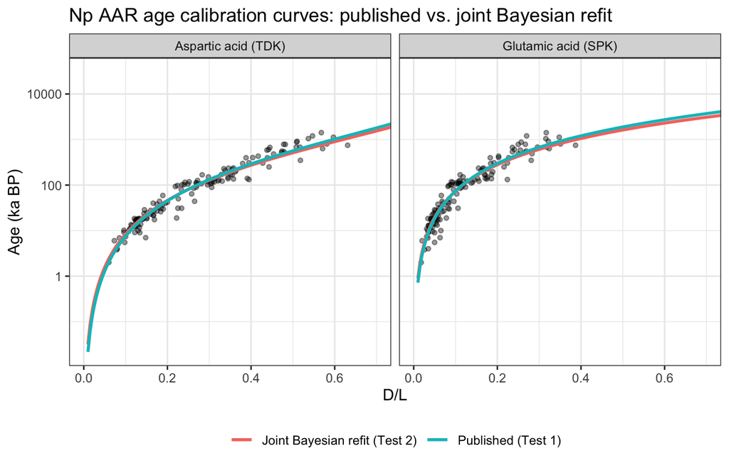

```r
dl_seq <- seq(0.01, 0.99, length.out = 200)
make_curves <- function(p, source) {
  rbind(
    data.frame(acid = "Aspartic acid (TDK)", DL = dl_seq,
               age_ka = predict_age_asp(dl_seq, p$a_Asp, p$e_Asp), source = source),
    data.frame(acid = "Glutamic acid (SPK)", DL = dl_seq,
               age_ka = predict_age_glu(dl_seq, p$a_Glu, p$e_Glu), source = source)
  )
}
curves_all <- rbind(make_curves(cst, "Published (Test 1)"),
                    make_curves(calib_params_B, "Joint Bayesian refit (Test 2)"))
obs <- rbind(
  data.frame(acid = "Aspartic acid (TDK)", DL = np$DL_Asp, age_ka = np$age_ka),
  data.frame(acid = "Glutamic acid (SPK)", DL = np$DL_Glu, age_ka = np$age_ka)
)

ggplot() +
  geom_point(data = obs, aes(x = DL, y = age_ka), size = 1.2, alpha = 0.4) +
  geom_line(data = curves_all, aes(x = DL, y = age_ka, colour = source), linewidth = 1) +
  scale_y_log10() +
  coord_cartesian(xlim = c(0, 0.7)) +
  facet_wrap(~acid, scales = "free_x") +
  labs(x = "D/L", y = "Age (ka BP)",
       title = "Np AAR age calibration curves: published vs. joint Bayesian refit",
       colour = NULL) +
  theme_bw() + theme(legend.position = "bottom")
```

### Full calibration-set comparison

Ages are inverted for all 140 samples from the joint refit (its own residual standard deviations and correlation, without per-sample leverage terms), and compared with the Asp-only calculator.

```r
full_results_B <- run_full_comparison(function(ref) calib_params_B, seed = 7)
range(full_results_B$acceptance)
```

```
#> [1] 0.33737 0.43860
```

```r
young_B <- full_results_B$published_age_ka < 50
old_B   <- full_results_B$published_age_ka > 500
fit_bias_B <- lm(pct_diff_median ~ log(published_age_ka), data = full_results_B)

data.frame(
  median_abs_pct_diff = median(abs(full_results_B$pct_diff_median)),
  max_abs_pct_diff    = max(abs(full_results_B$pct_diff_median)),
  median_pct_under_50ka = median(full_results_B$pct_diff_median[young_B]),
  median_pct_over_500ka = median(full_results_B$pct_diff_median[old_B]),
  slope_pct_per_efold = coef(fit_bias_B)[[2]],
  median_width_ratio  = median(full_results_B$bayes_width66 / full_results_B$asp_width66)
) |> knitr::kable(digits = 2,
                  col.names = c("Median abs. % diff", "Max abs. % diff",
                                "Median % diff, < 50 ka", "Median % diff, > 500 ka",
                                "Trend (% per e-fold in age)", "Median 66% width ratio"))
```

| Median abs. % diff | Max abs. % diff | Median % diff, < 50 ka | Median % diff, > 500 ka | Trend (% per e-fold in age) | Median 66% width ratio |
| --- | --- | --- | --- | --- | --- |
| 6.03 | 17.09 | 6.73 | -9.74 | -4.45 | 1 |

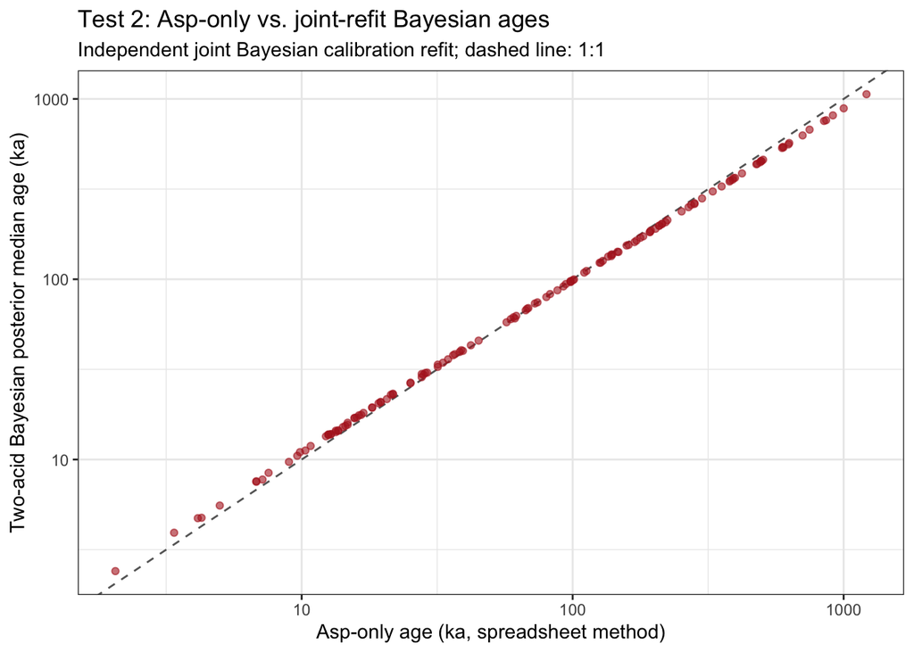

```r
ggplot(full_results_B, aes(x = asp_age_ka, y = bayes_median_ka)) +
  geom_abline(slope = 1, intercept = 0, linetype = "dashed", colour = "grey40") +
  geom_point(alpha = 0.6, colour = "firebrick") +
  scale_x_log10() + scale_y_log10() +
  labs(x = "Asp-only age (ka, spreadsheet method)",
       y = "Two-acid Bayesian posterior median age (ka)",
       title = "Test 2: Asp-only vs. joint-refit Bayesian ages",
       subtitle = "Independent joint Bayesian calibration refit; dashed line: 1:1") +
  theme_bw()
```

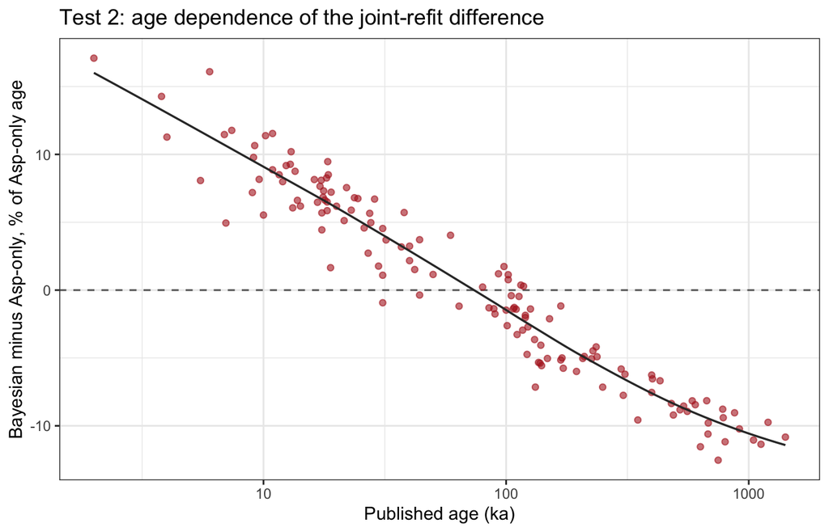

```r
ggplot(full_results_B, aes(x = published_age_ka, y = pct_diff_median)) +
  geom_hline(yintercept = 0, linetype = "dashed", colour = "grey40") +
  geom_point(alpha = 0.6, colour = "firebrick") +
  geom_smooth(method = "loess", formula = y ~ x, se = FALSE, colour = "grey20", linewidth = 0.6) +
  scale_x_log10() +
  labs(x = "Published age (ka)",
       y = "Bayesian minus Asp-only, % of Asp-only age",
       title = "Test 2: age dependence of the joint-refit difference") +
  theme_bw()
```

The joint refit returns calibration constants that differ from the published ones (table above), and its ages differ from the Asp-only calculator by a median of 6.0% and at most 17%. The difference is systematic with age, from a median of +7% below 50 ka to -10% above 500 ka (slope = -4.5% per e-fold in age, p 8.2e-84). Its origin is the residual correlation: jointly estimating `rho` alongside both curves’ shapes lets the sampler trade a small loss in each curve’s marginal fit for a gain in the joint bivariate-normal density, so the joint optimum is no longer the two curves’ independent OLS optima. Fixing `rho` at zero recovers the published constants to within 1.2% (largest difference across the six curve parameters), and the predicted ages to within a median of 0.4% (Monte Carlo and prior effects account for the residual). The 66% interval widths are similar (median ratio 1.00).

## Summary

**Test 1** (published constants) confirms that a Bayesian treatment of both amino acids returns the Asp-only age: with the same calibration and the same per-sample uncertainty, adding Glu changes the age by a median of 0.16% (exact posterior; 0.3% with Monte Carlo noise) and leaves the interval width unchanged. This follows from the calibration residuals: the observed Asp-Glu correlation (0.794) is almost exactly the ratio of the two residual standard deviations (0.795), the value at which Glu receives zero weight.

**Test 2** (independent joint Bayesian calibration refit) arrives at somewhat different calibration curves, and its ages differ from the Asp-only ages by a median of 6.0%, systematically with age. The divergence comes from estimating the residual correlation jointly with the curve shapes, not from a convergence failure, and its direction (younger ages at the old end) compounds the old-end young bias identified in the manuscript’s leave-one-out cross-validation. The independent per-acid fits are therefore preferred.

## Numbers cited in the manuscript

| quantity | value |
| --- | --- |
| Test 1: median abs. % difference, two-acid vs. Asp-only (MCMC) | 0.3140 |
| Test 1: median abs. % difference, two-acid vs. Asp-only (closed form) | 0.1635 |
| Test 1: max abs. % difference (closed form) | 7.9084 |
| Test 1: median 66% width ratio (MCMC) | 0.9970 |
| Two-acid sigma at calibration level (equals Asp-only sigma) | 0.3282 |
| Test 2: median abs. % difference | 6.0265 |
| Test 2: max abs. % difference | 17.0907 |
| Test 2: median % difference, < 50 ka | 6.7270 |
| Test 2: median % difference, > 500 ka | -9.7426 |
| Test 2: rho = 0 refit, max abs. % difference from published constants | 1.2150 |
| Test 2: rho = 0 refit, median abs. % difference in predicted Asp age | 0.3703 |
| Test 2: rho = 0 refit, median abs. % difference in predicted Glu age | 0.1762 |